# TP2 Analyse de données (avec tidyverse)

Arthur Leroy

24 novembre, 2020

## Avant propos

Dans le précédent document, nous avons introduit des outils utiles pour nettoyer une base de données, et visualiser directement une ou plusieurs de ses variables d'interêt. A présent, il est possible de faire usage de méthodes plus élaborées d'analyses de données, faisant appel à des notions d'algèbre linéaire, comme l'**anayse en composante principale** (ACP) ou l'**analyse factorielle des correspondances** (AFC). En termes pratiques, le package **FactoMineR** fournit un ensemble très complet d'implémentations de ces méthodes et d'autres.

## Exercice 4

Dans cet exercice, nous utilisons une base de données classique, nommée **swiss**, présente par défaut dans la version de base de R. Bien qu'il soit possible de l'utiliser telle quelle, on remarque que ce dataframe n'est pas au format **tidy** tel que définit dans le *tidyverse* : https://cran.r-project.org/web/packages/tidyr/vignettes/tidy-data.html . En effet, chaque ligne a un nom, et celui-ci devrait constituer plutôt une colonne du tableau. Ainsi, comme précédemment introduit, nous allons importer la base de données brute, puis créer une copie que l'on va mettre sous une forme correcte.

```r
library(tidyverse)
library(gridExtra)
library(FactoMineR)

raw_db = swiss

db = raw_db %>% rownames_to_column(var = 'Province') %>% as_tibble
db
```

```
## # A tibble: 47 x 7
##    Province Fertility Agriculture Examination Education Catholic
##    <chr>        <dbl>       <dbl>       <int>     <int>    <dbl>
##  1 Courtel~      80.2        17            15        12     9.96
##  2 Delemont      83.1        45.1           6         9    84.8
##  3 Franche~      92.5        39.7           5         5    93.4
##  4 Moutier       85.8        36.5          12         7    33.8
##  5 Neuvevi~      76.9        43.5          17        15     5.16
##  6 Porrent~      76.1        35.3           9         7    90.6
##  7 Broye         83.8        70.2          16         7    92.8
##  8 Glane         92.4        67.8          14         8    97.2
##  9 Gruyere       82.4        53.3          12         7    97.7
## 10 Sarine        82.9        45.2          16        13    91.4
## # ... with 37 more rows, and 1 more variable: Infant.Mortality <dbl>
```

Pour nous familiariser avec les données, nous pouvons utiliser quelques indicateurs et graphs descriptifs dans un premier temps.

```r
summary(db)
```

```
##    Province           Fertility      Agriculture     Examination
##  Length:47          Min.   :35.00   Min.   : 1.20   Min.   : 3.00
##  Class :character   1st Qu.:64.70   1st Qu.:35.90   1st Qu.:12.00
##  Mode  :character   Median :70.40   Median :54.10   Median :16.00
##                     Mean   :70.14   Mean   :50.66   Mean   :16.49
##                     3rd Qu.:78.45   3rd Qu.:67.65   3rd Qu.:22.00
##                     Max.   :92.50   Max.   :89.70   Max.   :37.00
##    Education        Catholic       Infant.Mortality
##  Min.   : 1.00   Min.   :  2.150   Min.   :10.80
##  1st Qu.: 6.00   1st Qu.:  5.195   1st Qu.:18.15
##  Median : 8.00   Median : 15.140   Median :20.00
##  Mean   :10.98   Mean   : 41.144   Mean   :19.94
##  3rd Qu.:12.00   3rd Qu.: 93.125   3rd Qu.:21.70
##  Max.   :53.00   Max.   :100.000   Max.   :26.60
```

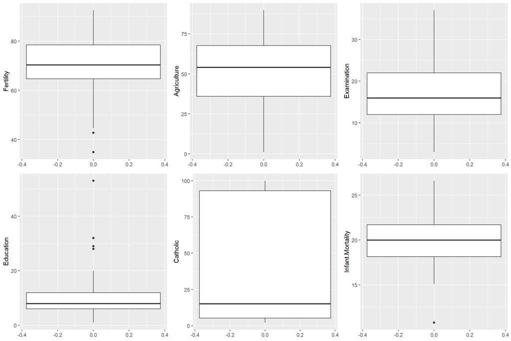

```r
gg1 = ggplot(db) + geom_boxplot(aes(y = Fertility))
gg2 = ggplot(db) + geom_boxplot(aes(y = Agriculture))
gg3 = ggplot(db) + geom_boxplot(aes(y = Examination))
gg4 = ggplot(db) + geom_boxplot(aes(y = Education))
gg5 = ggplot(db) + geom_boxplot(aes(y = Catholic))
gg6 = ggplot(db) + geom_boxplot(aes(y = Infant.Mortality))

grid.arrange(gg1, gg2, gg3, gg4, gg5, gg6, ncol = 3, nrow = 2)
```

Lorsque nous souhaitons afficher comme ceci le même type de graph pour un grand nombre de variable, il peut être plus pratique d'utiliser la fonction **gather()** du tidyverse. Cette fonction regroupe toutes les variables en un tibble avec seulement deux colonnes *key* et *value*, qui associé à l'argument *facet_wrap*, permet l'affichage de multiples graphs.

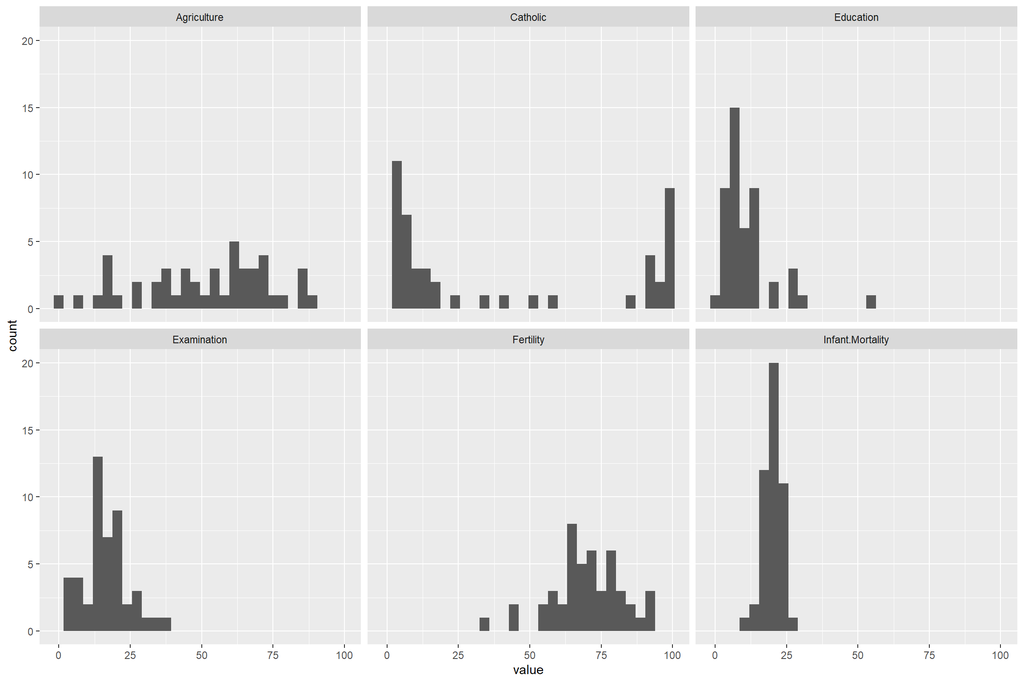

```r
db %>% select_if(is.numeric) %>%
       gather() %>%
       ggplot(aes(x = value)) + facet_wrap(~ key) + geom_histogram()
```

Utilisons maintenant la fonction **PCA()** du package *FactoMineR* pour réaliser une analyse en composantes principales. Nous choisissons un nombre de composantes égal à 6 (le nombre de variables est le maximum). Par défaut, la fonction affiche la projection des individus et des variables dans le plan factoriel défini par les deux premières composantes.

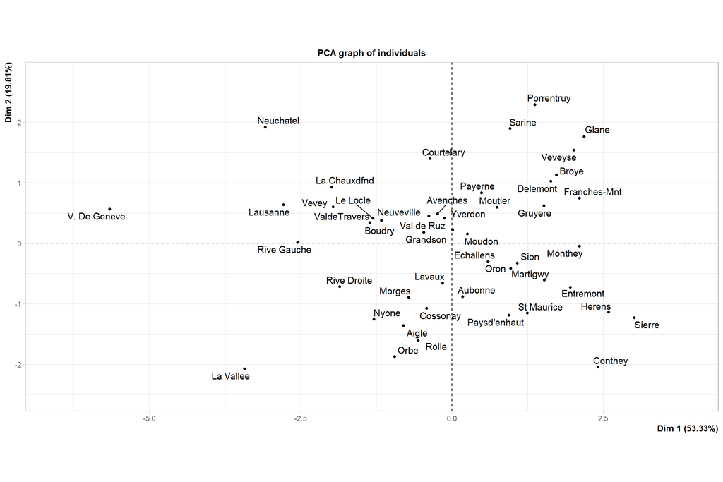

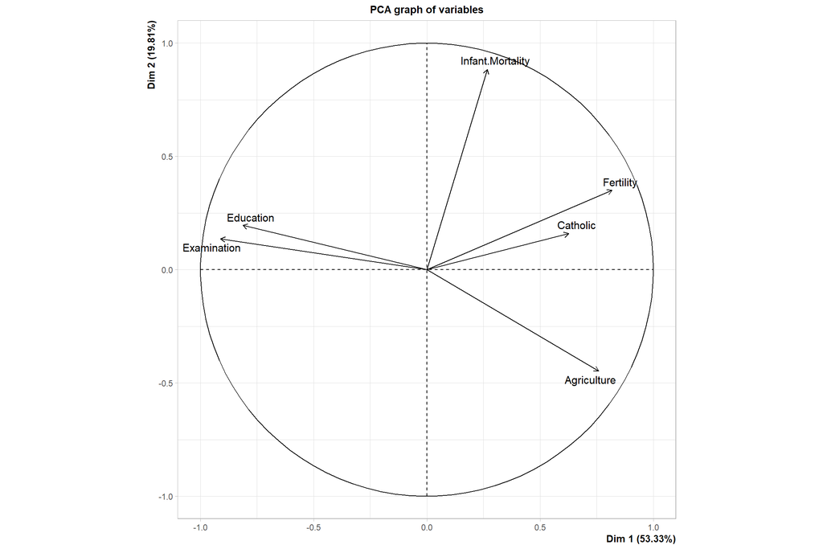

```r
swiss.acp = PCA(swiss, ncp = 6)
```

```r
summary(swiss.acp)
```

```
##
## Call:
## PCA(X = swiss, ncp = 6)
##
##
## Eigenvalues
##                        Dim.1   Dim.2   Dim.3   Dim.4   Dim.5   Dim.6
## Variance               3.200   1.188   0.848   0.439   0.205   0.121
## % of var.             53.329  19.805  14.127   7.315   3.409   2.014
## Cumulative % of var.  53.329  73.134  87.261  94.577  97.986 100.000
##
## Individuals (the 10 first)
##                      Dist    Dim.1    ctr   cos2    Dim.2    ctr   cos2
## Courtelary       |  2.034 | -0.364  0.088  0.032 |  1.399  3.506  0.473 |
## Delemont         |  2.169 |  1.634  1.776  0.568 |  1.026  1.885  0.224 |
## Franches-Mnt     |  2.764 |  2.104  2.944  0.580 |  0.746  0.997  0.073 |
## Moutier          |  1.596 |  0.748  0.372  0.219 |  0.596  0.636  0.139 |
## Neuveville       |  1.182 | -0.382  0.097  0.104 |  0.449  0.361  0.144 |
## Porrentruy       |  2.924 |  1.369  1.247  0.219 |  2.292  9.405  0.614 |
## Broye            |  2.310 |  1.724  1.977  0.557 |  1.128  2.277  0.238 |
## Glane            |  2.971 |  2.183  3.167  0.540 |  1.764  5.572  0.353 |
## Gruyere          |  1.873 |  1.518  1.532  0.657 |  0.623  0.694  0.110 |
## Sarine           |  2.247 |  0.962  0.615  0.183 |  1.895  6.431  0.711 |
##                   Dim.3    ctr   cos2
## Courtelary       -0.860  1.855  0.179 |
## Delemont          0.548  0.753  0.064 |
## Franches-Mnt      0.473  0.561  0.029 |
## Moutier          -0.579  0.842  0.132 |
## Neuveville       -0.628  0.991  0.283 |
## Porrentruy        0.351  0.308  0.014 |
## Broye             0.432  0.469  0.035 |
## Glane             0.398  0.398  0.018 |
## Gruyere           0.708  1.258  0.143 |
## Sarine            0.665  1.109  0.088 |
##
## Variables
##                     Dim.1    ctr   cos2    Dim.2    ctr   cos2    Dim.3    ctr
## Fertility        |  0.817 20.884  0.668 |  0.351 10.370  0.123 | -0.160  3.019
## Agriculture      |  0.759 17.996  0.576 | -0.449 16.934  0.201 |  0.035  0.147
## Examination      | -0.912 25.983  0.831 |  0.136  1.563  0.019 | -0.084  0.832
## Education        | -0.813 20.640  0.660 |  0.195  3.206  0.038 |  0.490 28.344
## Catholic         |  0.626 12.258  0.392 |  0.159  2.128  0.025 |  0.743 65.093
## Infant.Mortality |  0.268  2.240  0.072 |  0.884 65.799  0.782 | -0.147  2.563
##                    cos2
## Fertility         0.026 |
## Agriculture       0.001 |
## Examination       0.007 |
## Education         0.240 |
## Catholic          0.552 |
## Infant.Mortality  0.022 |
```

Traçons l'ébouli des valeurs propres pour déterminer les composantes pertinentes.

```r
vp = swiss.acp$eig %>% data.frame %>% rownames_to_column(var = 'Composante') %>% as_tibble

gg7 = ggplot(vp) + geom_col(aes(x = Composante, y = eigenvalue)) + ggtitle("Ebouli des valeurs propres")
```

En utilisant la règle de Kaiser, on peut voir graphiquement que l'on ne retiendrait que deux compostantes principales.

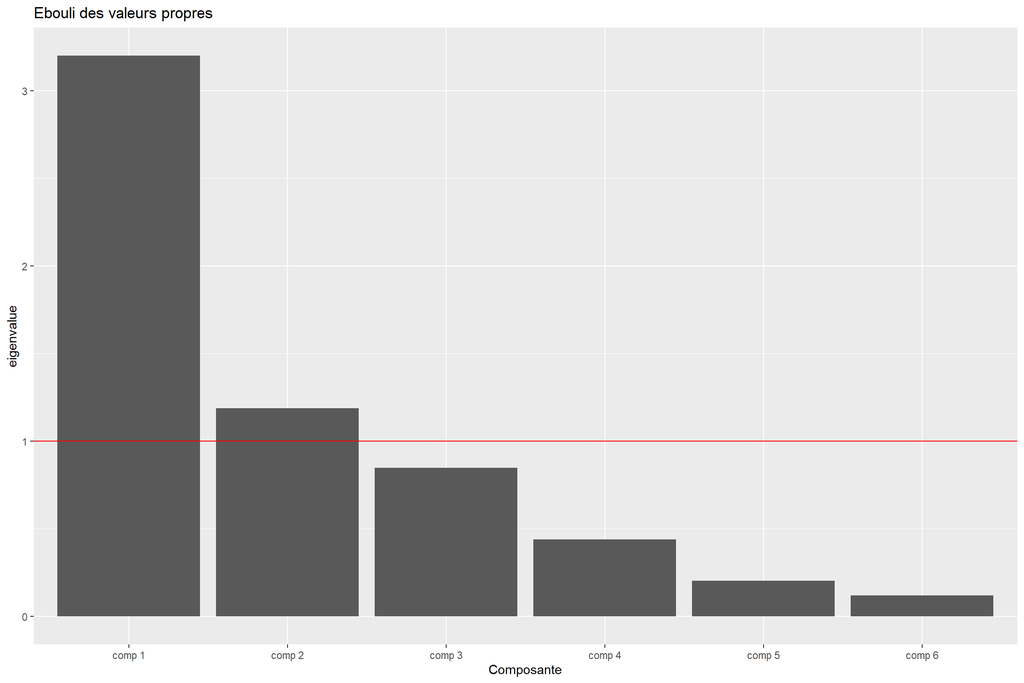

```r
gg7 + geom_hline(aes(yintercept = 1), color = 'red')
```

En utilisant le pourcentage de variance expliquée, on aurait pu retenir un nombre différent de composante. Par exemple si l'on souhaite retenir toutes celles qui expliquent plus de 10% de la variance.

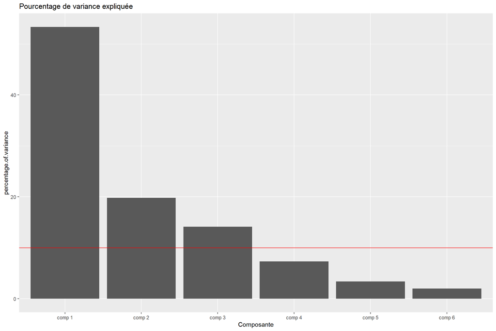

```r
ggplot(vp) + geom_col(aes(x = Composante, y = percentage.of.variance)) +
            ggtitle("Pourcentage de variance expliquée") + geom_hline(aes(yintercept = 10), color = 'red')
```

Ou encore si on voulait avoir un pourcentage de variance cumulée supérieur à 90%, auquel cas on retiendra les 4 premières.

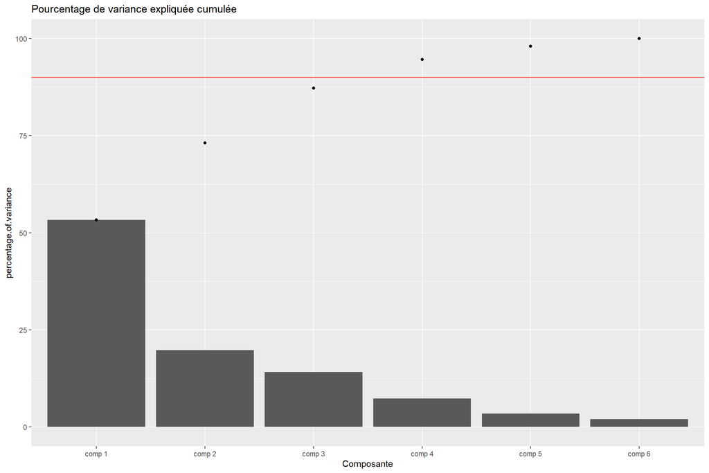

```r
ggplot(vp) + geom_col(aes(x = Composante, y = percentage.of.variance)) +
             geom_point(aes(x = Composante, y = cumulative.percentage.of.variance)) +
             ggtitle("Pourcentage de variance expliquée cumulée") +
             geom_hline(aes(yintercept = 90), color = 'red')
```

## Exercice 5

Avant toute chose, pour ce nouvel exercice, nous allons effacer tous les objets créés dans l'espace de travail pour eviter tout conflit/erreur avec la commande suivante:

```r
rm(list = ls())
```

Nous pouvons ensuite entamer une nouvelle analyse par la traditionelle importation des packages, des données et leur mise en forme. Nous utilisons ici la base de données **decathlon** inclue dans le package *FactoMineR*, regroupant les performances en compétition (JO et Décastar 2004) de différents athlètes dans les épreuves de décathlon.

```r
library(tidyverse)
library(gridExtra)
library(FactoMineR)

data(decathlon)
raw_db = decathlon

db = raw_db %>% rownames_to_column('Name') %>% as_tibble
db
```

```
## # A tibble: 41 x 14
##    Name  `100m` Long.jump Shot.put High.jump `400m` `110m.hurdle` Discus
##    <chr>  <dbl>     <dbl>    <dbl>     <dbl>  <dbl>         <dbl>  <dbl>
##  1 SEBR~   11.0      7.58     14.8      2.07   49.8          14.7   43.8
##  2 CLAY    10.8      7.4      14.3      1.86   49.4          14.0   50.7
##  3 KARP~   11.0      7.3      14.8      2.04   48.4          14.1   49.0
##  4 BERN~   11.0      7.23     14.2      1.92   48.9          15.0   40.9
##  5 YURK~   11.3      7.09     15.2      2.1    50.4          15.3   46.3
##  6 WARN~   11.1      7.6      14.3      1.98   48.7          14.2   41.1
##  7 ZSIV~   11.1      7.3      13.5      2.01   48.6          14.2   45.7
##  8 McMU~   10.8      7.31     13.8      2.13   49.9          14.4   44.4
##  9 MART~   11.6      6.81     14.6      1.95   50.1          14.9   47.6
## 10 HERNU   11.4      7.56     14.4      1.86   51.1          15.1   45.0
## # ... with 31 more rows, and 6 more variables: Pole.vault <dbl>,
## #   Javeline <dbl>, `1500m` <dbl>, Rank <int>, Points <int>, Competition <fct>
```

```r
summary(db)
```

```
##      Name                100m         Long.jump       Shot.put
##  Length:41          Min.   :10.44   Min.   :6.61   Min.   :12.68
##  Class :character   1st Qu.:10.85   1st Qu.:7.03   1st Qu.:13.88
##  Mode  :character   Median :10.98   Median :7.30   Median :14.57
##                     Mean   :11.00   Mean   :7.26   Mean   :14.48
##                     3rd Qu.:11.14   3rd Qu.:7.48   3rd Qu.:14.97
##                     Max.   :11.64   Max.   :7.96   Max.   :16.36
##    High.jump          400m        110m.hurdle        Discus
##  Min.   :1.850   Min.   :46.81   Min.   :13.97   Min.   :37.92
##  1st Qu.:1.920   1st Qu.:48.93   1st Qu.:14.21   1st Qu.:41.90
##  Median :1.950   Median :49.40   Median :14.48   Median :44.41
##  Mean   :1.977   Mean   :49.62   Mean   :14.61   Mean   :44.33
##  3rd Qu.:2.040   3rd Qu.:50.30   3rd Qu.:14.98   3rd Qu.:46.07
##  Max.   :2.150   Max.   :53.20   Max.   :15.67   Max.   :51.65
##    Pole.vault       Javeline         1500m            Rank           Points
##  Min.   :4.200   Min.   :50.31   Min.   :262.1   Min.   : 1.00   Min.   :7313
##  1st Qu.:4.500   1st Qu.:55.27   1st Qu.:271.0   1st Qu.: 6.00   1st Qu.:7802
##  Median :4.800   Median :58.36   Median :278.1   Median :11.00   Median :8021
##  Mean   :4.762   Mean   :58.32   Mean   :279.0   Mean   :12.12   Mean   :8005
##  3rd Qu.:4.920   3rd Qu.:60.89   3rd Qu.:285.1   3rd Qu.:18.00   3rd Qu.:8122
##  Max.   :5.400   Max.   :70.52   Max.   :317.0   Max.   :28.00   Max.   :8893
##    Competition
##  Decastar:13
##  OlympicG:28
##
##
##
##
```

Nous pouvons maintenant appliquer notre ACP, en retenant les variables d'intérêt, les performances dans chaque épreuve, tout en écartant les variables non pertinentes (le nombre de points et le classement, qui sont juste la conséquence de la somme de toutes les autres). Comme la fonction PCA() permet l'affichage des individus seulement pour des bases de données comportant des noms de lignes (à éviter normalement, contraire au format *tidy*), nous utilisons exceptionnelement la base de données brute en argument.

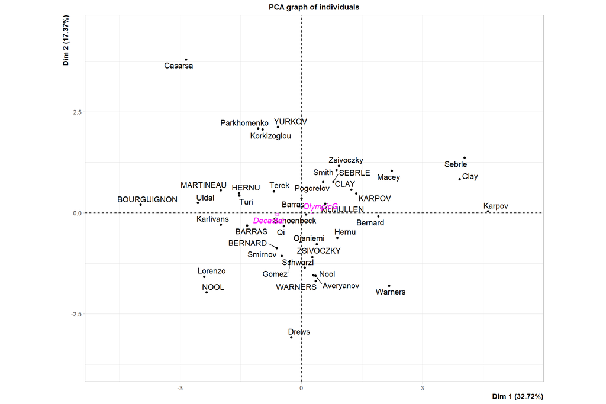

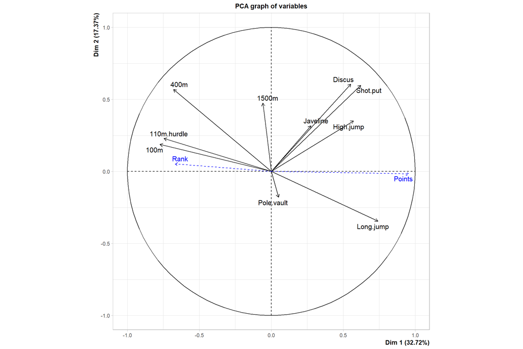

```r
deca_acp = PCA(raw_db, ncp = 10, quanti.sup=c(11,12), quali.sup=  13)
```

L'analyse de la projection des variables sur le plan factoriel revele des premières informations, notamment la nette distinction entre les disciplines de *course* et les disciplines de lancés/sauts. Cette distinction est très classique dans le milieu du décathlon, et se joue souvent au niveau de la morphologie des athlètes, notamment dans le compromis poids/vitesse/puissance. Le 1500m est traditionnement l'épreuve qui illustre le mieux cette recherche de la polyvalence, et son placement intermédiaire sur le premier axe factoriel le montre parfaitement. Bien que ne servant pas dans le calcul des axes, les variables supplémentaires *Points* et *Rank* sont parfaitement anticorrélés, ce qui est tout à fait normal par définition du système de classement. On peut noter que les variables à gauche du graphique sont celles dont des valeurs faibles indiquent une bonne performance (temps le plus rapide possible) alors que les variables de droite représentent des valeurs qui doivent être maximiser (sauter ou lancer le plus loin possible). Ce implique que le premier axe renseigne également sur le niveau des athlètes lorsque l'on projet les individus sur le plans factoriel. Ceux qui obtiennent les meilleurs résultats sont à droite, alors que les moins bons se retrouvent sur la gauche.

Regardons plus en profondeur les résultats de cette ACP avec un résumé des axes, et de l'influence des individus et des variables.

```r
summary(deca_acp)
```

```
##
## Call:
## PCA(X = raw_db, ncp = 10, quanti.sup = c(11, 12), quali.sup = 13)
##
##
## Eigenvalues
##                        Dim.1   Dim.2   Dim.3   Dim.4   Dim.5   Dim.6   Dim.7
## Variance               3.272   1.737   1.405   1.057   0.685   0.599   0.451
## % of var.             32.719  17.371  14.049  10.569   6.848   5.993   4.512
## Cumulative % of var.  32.719  50.090  64.140  74.708  81.556  87.548  92.061
##                        Dim.8   Dim.9  Dim.10
## Variance               0.397   0.215   0.182
## % of var.              3.969   2.148   1.822
## Cumulative % of var.  96.030  98.178 100.000
##
## Individuals (the 10 first)
##                 Dist    Dim.1    ctr   cos2    Dim.2    ctr   cos2    Dim.3
## SEBRLE      |  2.369 |  0.792  0.467  0.112 |  0.772  0.836  0.106 |  0.827
## CLAY        |  3.507 |  1.235  1.137  0.124 |  0.575  0.464  0.027 |  2.141
## KARPOV      |  3.396 |  1.358  1.375  0.160 |  0.484  0.329  0.020 |  1.956
## BERNARD     |  2.763 | -0.610  0.277  0.049 | -0.875  1.074  0.100 |  0.890
## YURKOV      |  3.018 | -0.586  0.256  0.038 |  2.131  6.376  0.499 | -1.225
## WARNERS     |  2.428 |  0.357  0.095  0.022 | -1.685  3.986  0.482 |  0.767
## ZSIVOCZKY   |  2.563 |  0.272  0.055  0.011 | -1.094  1.680  0.182 | -1.283
## McMULLEN    |  2.561 |  0.588  0.257  0.053 |  0.231  0.075  0.008 | -0.418
## MARTINEAU   |  3.742 | -1.995  2.968  0.284 |  0.561  0.442  0.022 | -0.730
## HERNU       |  2.794 | -1.546  1.782  0.306 |  0.488  0.335  0.031 |  0.841
##                ctr   cos2
## SEBRLE       1.187  0.122 |
## CLAY         7.960  0.373 |
## KARPOV       6.644  0.332 |
## BERNARD      1.375  0.104 |
## YURKOV       2.606  0.165 |
## WARNERS      1.020  0.100 |
## ZSIVOCZKY    2.857  0.250 |
## McMULLEN     0.303  0.027 |
## MARTINEAU    0.925  0.038 |
## HERNU        1.227  0.091 |
##
## Variables
```

[output cut: 20 more lines]

```
## Javeline     0.152 |
## 1500m        0.612 |
##
## Supplementary continuous variables
##                Dim.1   cos2    Dim.2   cos2    Dim.3   cos2
## Rank        | -0.671  0.450 |  0.051  0.003 | -0.058  0.003 |
## Points      |  0.956  0.914 | -0.017  0.000 | -0.066  0.004 |
##
## Supplementary categories
##                 Dist    Dim.1   cos2 v.test    Dim.2   cos2 v.test    Dim.3
## Decastar    |  0.946 | -0.600  0.403 -1.430 | -0.038  0.002 -0.123 |  0.289
## OlympicG    |  0.439 |  0.279  0.403  1.430 |  0.017  0.002  0.123 | -0.134
##               cos2 v.test
## Decastar     0.093  1.050 |
## OlympicG     0.093 -1.050 |
```

Nous pouvons évaluer la qualité de représentation des individus en calculant le cosinus au carré de l'angle entre chaque individu et les deux premières composantes principales. La somme pour chaque ligne est égale à 1, ce qui correspond à la contribution totale.

```r
deca_acp$ind$cos2
```

```
##                    Dim.1        Dim.2        Dim.3        Dim.4        Dim.5
## SEBRLE      1.116789e-01 1.061026e-01 1.218353e-01 0.2458834524 0.0891175533
## CLAY        1.240094e-01 2.684265e-02 3.727871e-01 0.0102377459 0.3170100676
## KARPOV      1.599189e-01 2.030911e-02 3.317531e-01 0.2987884939 0.0548190497
## BERNARD     4.867778e-02 1.002326e-01 1.037729e-01 0.6461113208 0.0171358470
## YURKOV      3.769960e-02 4.985821e-01 1.648055e-01 0.0837901520 0.1719330517
## WARNERS     2.160805e-02 4.816432e-01 9.968563e-02 0.0589152534 0.1702119336
## ZSIVOCZKY   1.124289e-02 1.821025e-01 2.504698e-01 0.4002469595 0.0002956720
## McMULLEN    5.261548e-02 8.114872e-03 2.658664e-02 0.3541411987 0.0096431236
## MARTINEAU   2.843007e-01 2.247270e-02 3.804678e-02 0.0209913701 0.1778554736
## HERNU       3.061041e-01 3.054416e-02 9.052696e-02 0.0140466868 0.0070708236
## BARRAS      4.724688e-01 2.537270e-02 3.561105e-08 0.1092831998 0.0262577113
## NOOL        3.943464e-01 2.772902e-01 1.280937e-01 0.0027353957 0.0494306465
## BOURGUIGNON 8.568416e-01 2.161703e-03 9.522441e-02 0.0148794511 0.0045517341
## Sebrle      6.954102e-01 7.954314e-02 3.584905e-03 0.1606656530 0.0060588462
## Clay        7.112052e-01 3.243204e-02 2.474266e-03 0.1033352389 0.0498460233
## Karpov      8.517553e-01 6.383365e-05 6.901180e-05 0.0688510249 0.0014063664
## Macey       4.230486e-01 9.203950e-02 2.947774e-01 0.0468447512 0.0809958841
## Warners     5.299437e-01 3.664716e-01 8.162612e-02 0.0091289511 0.0025832911
## Zsivoczky   1.299979e-01 2.074432e-01 3.315678e-01 0.0990639959 0.1157524249
## Hernu       2.375133e-01 1.149269e-01 2.424855e-01 0.0054592252 0.1211641560
## Nool        9.085645e-03 2.488948e-01 1.913628e-01 0.5041363312 0.0001304805
## Bernard     4.546366e-01 9.210522e-04 7.172513e-02 0.2633835151 0.0146021897
## Schwarzl    1.692391e-03 4.716030e-01 1.741587e-01 0.0410045776 0.0214085579
## Pogorelov   5.129333e-02 1.046216e-01 3.198363e-01 0.0536930532 0.1664903797
## Schoenbeck  4.055023e-03 4.917858e-04 1.697632e-01 0.2671745019 0.2260760826
## Barras      9.304287e-07 2.625220e-02 4.981683e-01 0.0758215580 0.0921378551
## Smith       6.056788e-02 8.973312e-02 2.159712e-01 0.1005444484 0.3262548852
## Averyanov   1.918587e-02 3.823331e-01 1.256292e-02 0.0001169776 0.0205083363
## Ojaniemi    2.644231e-02 1.091967e-01 2.518177e-02 0.0864446226 0.0456162410
## Smirnov     5.746318e-02 2.753785e-01 3.693280e-01 0.0784257130 0.0405842640
## Qi          6.062787e-02 3.416535e-02 3.675892e-01 0.0134945074 0.0921372308
## Drews       5.279320e-03 8.106930e-01 9.498558e-02 0.0355995805 0.0027173219
## Parkhomenko 9.413024e-02 3.606112e-01 8.230215e-02 0.1938156221 0.0065362449
## Terek       4.316993e-02 2.663035e-02 4.530158e-01 0.0010952579 0.1010116137
## Gomez       1.231257e-02 2.098296e-01 2.499419e-01 0.0008880035 0.2331396438
## Turi        2.524637e-01 1.937904e-02 2.806770e-02 0.0021671053 0.0001592206
## Lorenzo     4.708005e-01 2.033589e-01 1.831808e-01 0.0073546458 0.0377447850
## Karlivans   5.439001e-01 1.183427e-02 1.606751e-02 0.2212739426 0.0190475658
## Korkizoglou 5.806095e-02 2.702279e-01 4.233992e-01 0.0898404437 0.0405932955
```

[output cut: 29 more lines]

```
## Smith       1.334385e-01 0.0690757200 0.0008512507 2.923333e-03 6.396704e-04
## Averyanov   5.981593e-02 0.2875194826 0.0917587715 8.885553e-02 3.734310e-02
## Ojaniemi    1.156401e-01 0.0094809343 0.4861245535 4.677378e-02 4.909898e-02
## Smirnov     6.042182e-03 0.0330055769 0.0175932939 5.068219e-02 7.149711e-02
## Qi          5.862170e-02 0.2883898169 0.0101829283 2.418912e-02 5.060228e-02
## Drews       3.081120e-03 0.0182254814 0.0257563918 4.916541e-04 3.170537e-03
## Parkhomenko 4.520717e-05 0.2448142236 0.0037539886 1.091170e-03 1.289996e-02
## Terek       1.418962e-01 0.0441602407 0.1630461994 1.405864e-02 1.191577e-02
## Gomez       3.638920e-02 0.0029906882 0.0013694640 2.342094e-02 2.297180e-01
## Turi        2.660406e-01 0.1771262390 0.2508770664 2.296868e-03 1.422452e-03
## Lorenzo     3.777958e-04 0.0112162337 0.0757542118 7.911033e-03 2.301023e-03
## Karlivans   4.371247e-02 0.1291605685 0.0019296046 1.046973e-02 2.604190e-03
## Korkizoglou 4.082232e-02 0.0017278908 0.0591722834 3.666211e-03 1.248953e-02
## Uldal       4.521809e-03 0.0285355773 0.0002684617 1.235601e-06 2.258501e-07
## Casarsa     2.979952e-04 0.0029071472 0.0018628266 1.054091e-02 4.610948e-03
```

Nous pouvons évaluer la qualité de représentation des variables en calculant le cosinus au carré de l'angle entre chaque variable et les deux premières composantes principales. La somme pour chaque ligne est égale à 1, ce qui correspond à la contribution totale. On remarque ce qui apparaissait déjà sur les premiers graphs, à savoir que la perche, le javelot et le 1500m contribue très peu au premier axe, indiquant leur faible influence sur le total de points. Il est en effet connu que ces épreuves font en pratique peu de différences. Les deux premières étant surtout 'éliminatoires' en cas de 0 (aucune barre passée à la perche par exemple), et le 1500m étant la dernière épreuve qui confirme souvent des positions déjà largement figées. Au contraire du premier, le troisième axe factoriel se concentre justement sur ces trois disciplines, et il pourrait être intéressant de le visualiser si l'on veut se pencher sur leur analyse spécifique.

```r
deca_acp$var$cos2
```

```
##                   Dim.1      Dim.2        Dim.3        Dim.4       Dim.5
## 100m        0.600190812 0.03502213 0.0340059930 0.0014302206 0.091322660
## Long.jump   0.550415232 0.11931587 0.0332008675 0.0103603165 0.001345279
## Shot.put    0.387509426 0.35796686 0.0005465513 0.0363251605 0.012354505
## High.jump   0.327121422 0.12270561 0.0673464410 0.0183857880 0.308513117
## 400m        0.461869674 0.32425938 0.0172842817 0.0008586058 0.007689811
## 110m.hurdle 0.556882084 0.05234639 0.0085816841 0.0845826853 0.027001375
## Discus      0.305219255 0.36761593 0.0018448960 0.0674292539 0.010988725
## Pole.vault  0.002534268 0.03252860 0.4785272696 0.3041897208 0.108873151
## Javeline    0.076790421 0.10048206 0.1518313365 0.5073389244 0.093103658
## 1500m       0.003372945 0.22488818 0.6117473613 0.0259496775 0.023581254
##                   Dim.6       Dim.7        Dim.8       Dim.9      Dim.10
## 100m        0.052532985 0.065768884 8.456508e-02 0.002357417 0.032803826
## Long.jump   0.056158895 0.177786116 1.752168e-04 0.050045300 0.001196908
## Shot.put    0.055920005 0.043286926 3.911301e-02 0.039220335 0.027757216
## High.jump   0.131125895 0.003773728 6.210295e-03 0.012753657 0.002064046
## 400m        0.066261577 0.006985401 1.807328e-02 0.065485634 0.031232355
## 110m.hurdle 0.005949349 0.057615948 2.006940e-01 0.004841992 0.001504535
## Discus      0.121013911 0.083390649 5.849093e-04 0.005148092 0.036764380
## Pole.vault  0.041030940 0.004330144 1.258004e-02 0.001479064 0.013926802
## Javeline    0.015961591 0.005141616 3.480612e-02 0.013140353 0.001403912
## 1500m       0.053313533 0.003155852 7.467951e-05 0.020343009 0.033573506
```

Pour selectionner le nombre adéquat de composante, on peut se reposer sur l'ébouli des valeurs propres et la règle de Kayser.

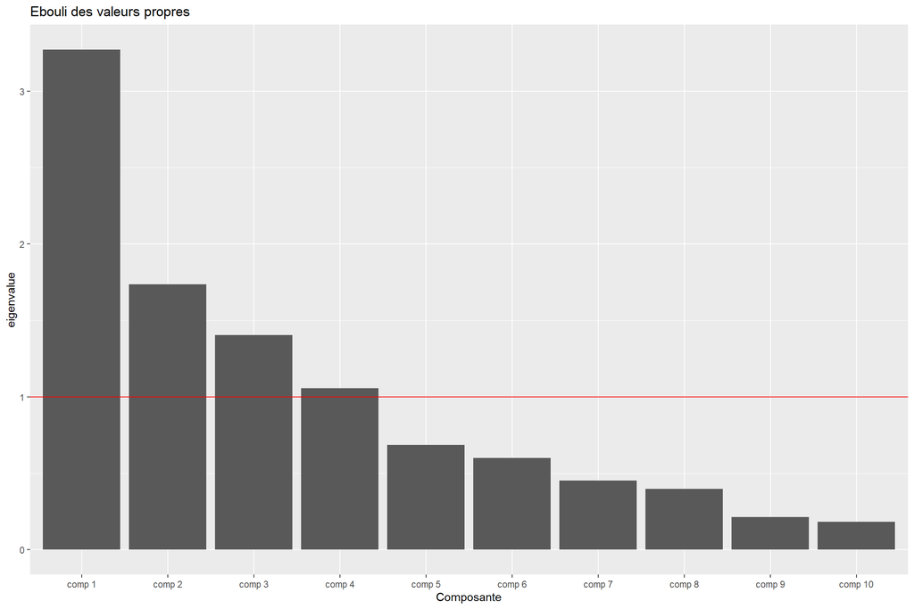

```r
vp = deca_acp$eig %>% data.frame %>% rownames_to_column(var = 'Composante') %>% as_tibble

vp %>% mutate(Composante = factor(Composante, levels = Composante)) %>%
       ggplot() + geom_col(aes(x = Composante, y = eigenvalue)) + ggtitle("Ebouli des valeurs propres") +
       geom_hline(aes(yintercept = 1), color = 'red')
```

Ou utiliser notre propre critère en se basant sur le pourcentage de variance expliquée.

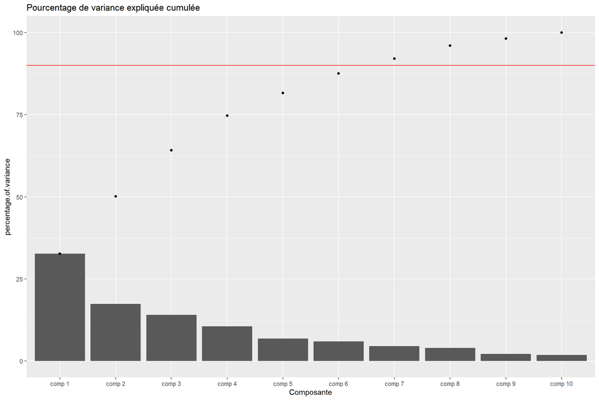

```r
vp %>% mutate(Composante = factor(Composante, levels = Composante)) %>%
       ggplot() + geom_col(aes(x = Composante, y = percentage.of.variance)) +
             geom_point(aes(x = Composante, y = cumulative.percentage.of.variance)) +
             ggtitle("Pourcentage de variance expliquée cumulée") +
             geom_hline(aes(yintercept = 90), color = 'red')
```

Une fois que l'on a selectionné le nombre de composantes, disons 4 ici. Nous pouvons visualiser les variables et individus dans de nouveaux plans factoriels. Cependant, les options graphiques restent assez limitées pour la fonction plot() définie dans le package.

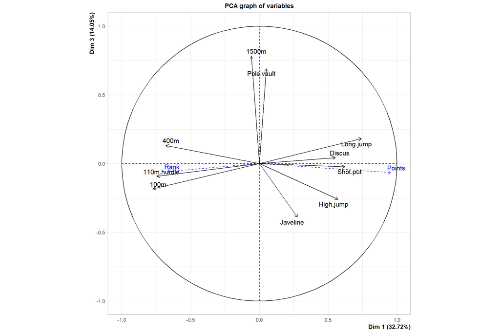

```r
plot(deca_acp, axes = c(1,3), choix="var")
```

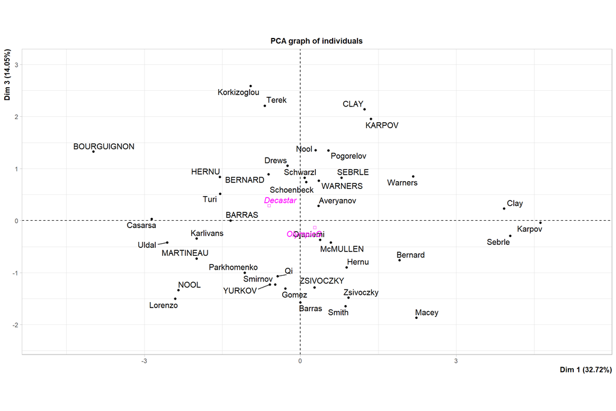

```r
plot(deca_acp, axes = c(1,3), choix="ind")
```

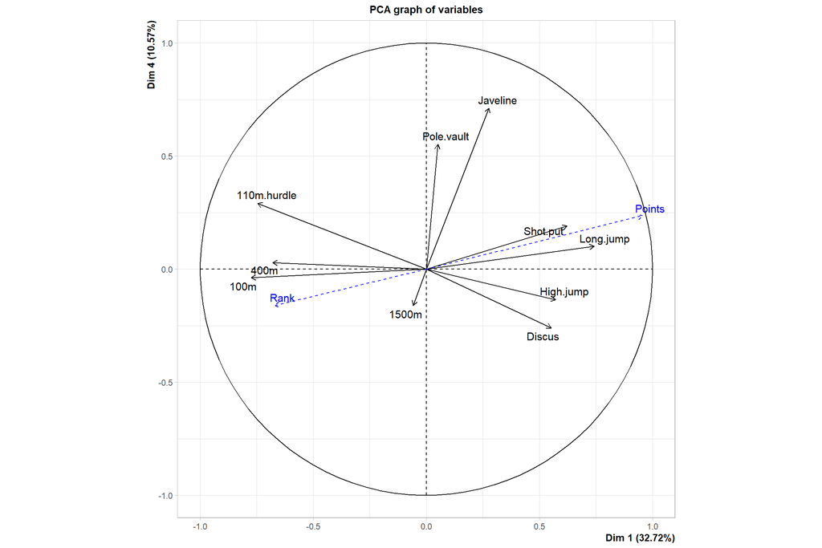

```r
plot(deca_acp, axes = c(1,4), choix="var")
```

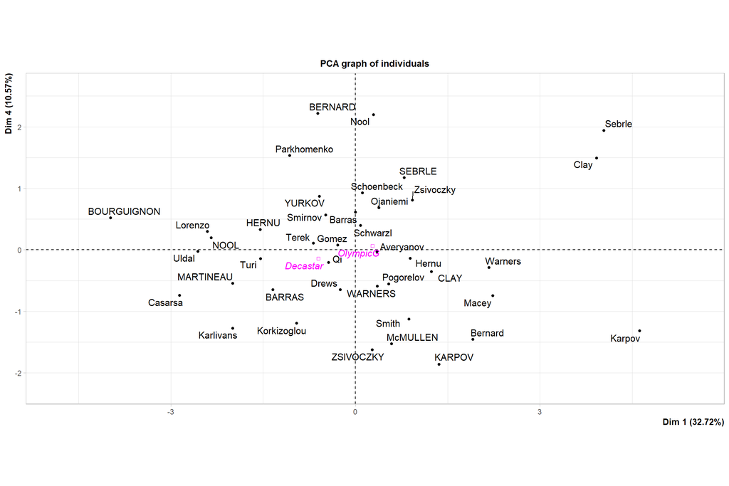

```r
plot(deca_acp, axes = c(1,4), choix="ind")
```

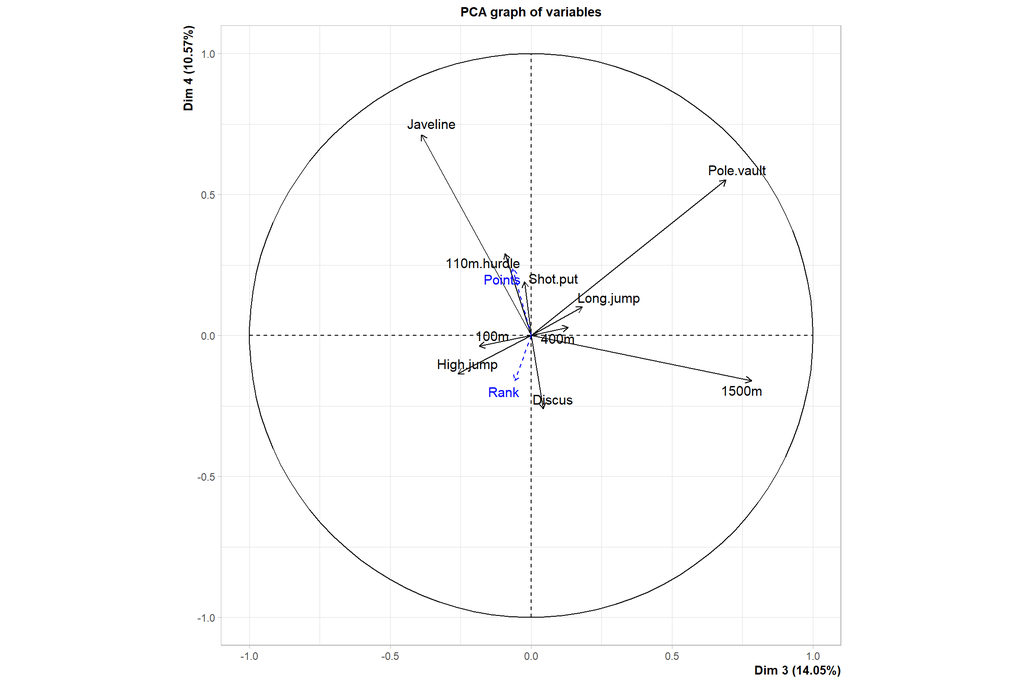

```r
plot(deca_acp, axes = c(3,4), choix="var")
```

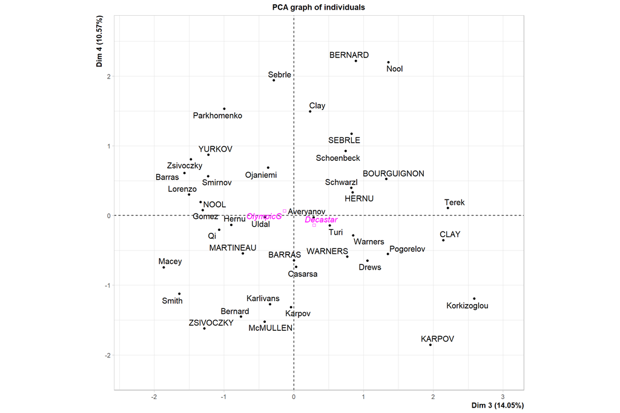

```r
plot(deca_acp, axes = c(3,4), choix="ind")
```

## Exercice 6

Pour cette exercice, nous ré-utilisons la base de données **Recensement_12**, mais nous introduisons une nouvelle méthode permettant d'analyser également les variables qualitatives: l'**analyse factorielle des correspondances (AFC)**. Il a été vu en cours que l'AFC utilise un tableau de contingence entre deux variables qualitatives. Il n'est donc plus questions d'individus ou de variables dans le tableau analysé, les lignes représentant les modalités d'une variables, et les colonnes les modalités de l'autre. En comptant les associations entres les différentes modalités de chaque variable, il est ensuite possible de fabriquer des *profils lignes* et *profils colonnes* à partir des fréquences conditionelles de chaque modalités. Puisque l'AFC correspond à une ACP utilisant la distance du $\chi^2$ sur un tel tableau, le fonctionnement de l'analyse et l'interprétation des résultats est globalement ressemblante aux précédents exercices. Commençons par les importations, et le nettoyage des données manquantes, et le décompte des modalités communes entre les variables du *statut marital* et des *revenus du foyer*:

```r
library(tidyverse)
library(gridExtra)
library(FactoMineR)

raw_db = read_csv2('C:/Users/user/Google Drive/Travail/Enseignement/STID/2A/ADD/Codes R/Donnees/Recensement_12.csv')
db  = raw_db %>% filter( !is.na(REV_FOYER), !is.na(STAT_MARI) ) %>%
                 group_by(STAT_MARI, REV_FOYER) %>%
                 count()
db
```

```
## # A tibble: 17 x 3
## # Groups:   STAT_MARI, REV_FOYER [17]
##    STAT_MARI REV_FOYER      n
##    <chr>     <chr>      <int>
##  1 C         < 40          72
##  2 C         >= 100        30
##  3 C         40 - < 60     39
##  4 C         60 - < 100    29
##  5 D         < 40          25
##  6 D         >= 100         8
##  7 D         40 - < 60      9
##  8 D         60 - < 100    12
##  9 M         < 40          56
## 10 M         >= 100        68
## 11 M         40 - < 60     66
## 12 M         60 - < 100   100
## 13 S         < 40           6
## 14 S         40 - < 60      4
## 15 S         60 - < 100     2
## 16 V         < 40           3
## 17 V         60 - < 100     2
```

On peut représenter sous la forme d'un tableau de contingence si nécessaire en utilisant la fonction **spread** qui, comme son nom l'indique, permet de déployer les modalités d'une variable en colonnes. L'argument *fill* remplace les NA par la valeur indiquée.

```r
tb_cont = db %>% spread(REV_FOYER, n, fill = 0)
tb_cont
```

```
## # A tibble: 5 x 5
## # Groups:   STAT_MARI [5]
##   STAT_MARI `< 40` `>= 100` `40 - < 60` `60 - < 100`
##   <chr>      <dbl>    <dbl>       <dbl>        <dbl>
## 1 C             72       30          39           29
## 2 D             25        8           9           12
## 3 M             56       68          66          100
## 4 S              6        0           4            2
## 5 V              3        0           0            2
```

Il existe plusieurs façon de calculer les fréquences nécessaires à la définition des profils lignes et colonnes, mais en passant par le format *tibble*, il est possible de le faire assez naturellement.

```r
prof_row = db %>% group_by(STAT_MARI) %>%
                  mutate(n = (n/sum(n)*100) %>% round()) %>%
                  spread(REV_FOYER, n, fill=0)
prof_row
```

```
## # A tibble: 5 x 5
## # Groups:   STAT_MARI [5]
##   STAT_MARI `< 40` `>= 100` `40 - < 60` `60 - < 100`
##   <chr>      <dbl>    <dbl>       <dbl>        <dbl>
## 1 C             42       18          23           17
## 2 D             46       15          17           22
## 3 M             19       23          23           34
## 4 S             50        0          33           17
## 5 V             60        0           0           40
```

On remarque que les lignes somment bien à 100%, et on peut déjà voir à l'oeil nu la ressemblance entre certaines lignes, notamment les modalités **Célibataire (C)** et **Divorcé (D)**. Gardons ça à l'esprit pour l'AFC qui suit et faisons la même chose pour les profils colonnes.

```r
prof_col= db %>% group_by(REV_FOYER) %>%
                 mutate(n = (n/sum(n)*100) %>% round()) %>%
                 spread(STAT_MARI, n, fill=0)
prof_col
```

```
## # A tibble: 4 x 6
## # Groups:   REV_FOYER [4]
##   REV_FOYER      C     D     M     S     V
##   <chr>      <dbl> <dbl> <dbl> <dbl> <dbl>
## 1 < 40          44    15    35     4     2
## 2 >= 100        28     8    64     0     0
## 3 40 - < 60     33     8    56     3     0
## 4 60 - < 100    20     8    69     1     1
```

Dans le cas des revenus, on peut voir une très forte similarité entre les modalités *60-100* et *>100*, qui sont globalements des profils de foyers très aisés. A présent, on souhaite effectuer une AFC sur le tableau de contingence en utilisant le package **FactoMineR**, et sa fonction correspondante *CA()*. Si on note $m_1 = 5$ et $m_2 = 4$ le nombre de modalités pour respectivement la première et la deuxième variable, le nombre maximal d'axes est données par $min(m_1, m_2) - 1 = 3$ dans notre cas.

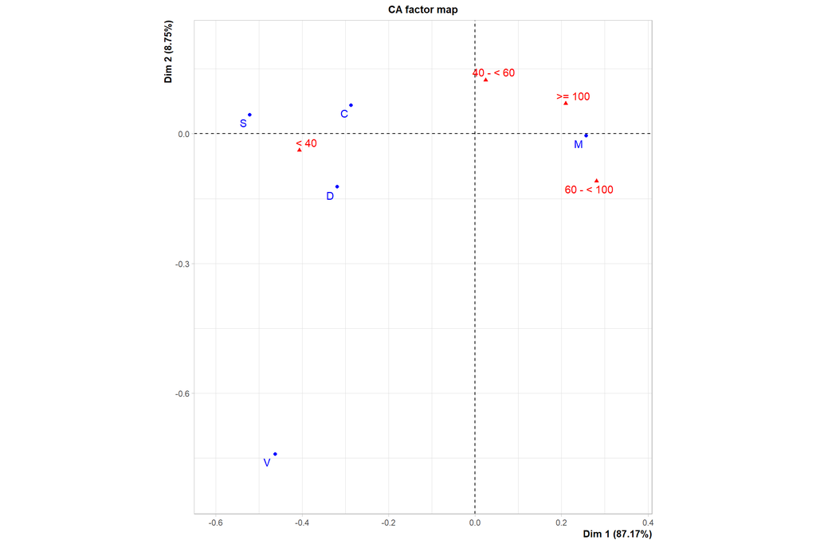

```r
res_ca = CA(tb_cont %>% column_to_rownames('STAT_MARI'), ncp = 3)
```

L'ACP est réalisée à la fois sur les profils lignes et les profils colonnes, ce qui amène ci-dessus aux projections sur les axes factoriels pour les deux ensembles de modalités. Regardons à présent un résumé des informations importantes de notre AFC.

```r
summary(res_ca)
```

```
##
## Call:
## CA(X = tb_cont %>% column_to_rownames("STAT_MARI"), ncp = 3)
##
## The chi square of independence between the two variables is equal to 49.31637 (p-value =  1.841341e-06 ).
##
## Eigenvalues
##                        Dim.1   Dim.2   Dim.3
## Variance               0.081   0.008   0.004
## % of var.             87.167   8.754   4.078
## Cumulative % of var.  87.167  95.922 100.000
##
## Rows
##              Iner*1000    Dim.1    ctr   cos2    Dim.2    ctr   cos2    Dim.3
## C          |    27.969 | -0.287 32.574  0.943 |  0.066 16.932  0.049 |  0.026
## D          |    12.034 | -0.319 12.754  0.858 | -0.122 18.732  0.127 |  0.043
## M          |    36.141 |  0.257 44.599  0.999 | -0.005  0.147  0.000 | -0.007
## S          |     9.518 | -0.521  7.586  0.645 |  0.044  0.527  0.005 | -0.384
## V          |     7.212 | -0.462  2.487  0.279 | -0.741 63.663  0.718 | -0.049
##               ctr   cos2
## C           5.859  0.008 |
## D           4.894  0.015 |
## M           0.638  0.001 |
## S          88.021  0.350 |
## V           0.588  0.003 |
##
## Columns
##              Iner*1000    Dim.1    ctr   cos2    Dim.2    ctr   cos2    Dim.3
## < 40       |    50.977 | -0.407 62.335  0.990 | -0.039  5.568  0.009 |  0.014
## >= 100     |    11.925 |  0.210 10.845  0.736 |  0.070 12.086  0.082 |  0.104
## 40 - < 60  |     4.906 |  0.025  0.165  0.027 |  0.124 42.184  0.699 | -0.078
## 60 - < 100 |    25.067 |  0.281 26.655  0.861 | -0.109 40.162  0.130 | -0.029
##               ctr   cos2
## < 40        1.589  0.001 |
## >= 100     57.108  0.181 |
## 40 - < 60  35.428  0.274 |
## 60 - < 100  5.876  0.009 |
```

On voit que le premier axe exprime à lui seul une énorme part de la variance, et les deux premiers axes dépassent les 95% de variances cumulée à eux seuls. On voit que la règle de Kayser n'est ici pas applicable car les valeurs propres sont toutes <1. On remarque sur le graphe comme dans le résumé des contributions que la modalité *Veuf* perturbe l'analyse à cause de son faible effectif. Nous allons donc refaire l'analyse en l'utilisant comme modalité supplémentaire qui n'intervient pas dans la construction des axes.

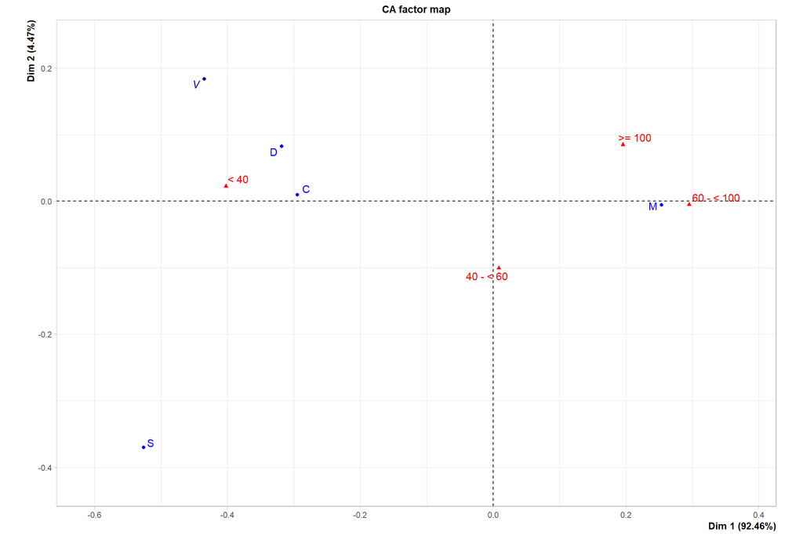

```r
res_ca2 = CA(tb_cont %>% column_to_rownames('STAT_MARI'), ncp = 3, row.sup = 5)
```

On s'aperçoit alors que la modalité *Séparé* présente le même comportement, avec elle aussi un petit effectif. On va donc relancer une dernière fois l'analyse en ne conservant que les 3 modalités bien représentées. Attention, à cause de ce choix, notre nombre d'axe maximal est maintenant égale à 3 - 1 = 2.

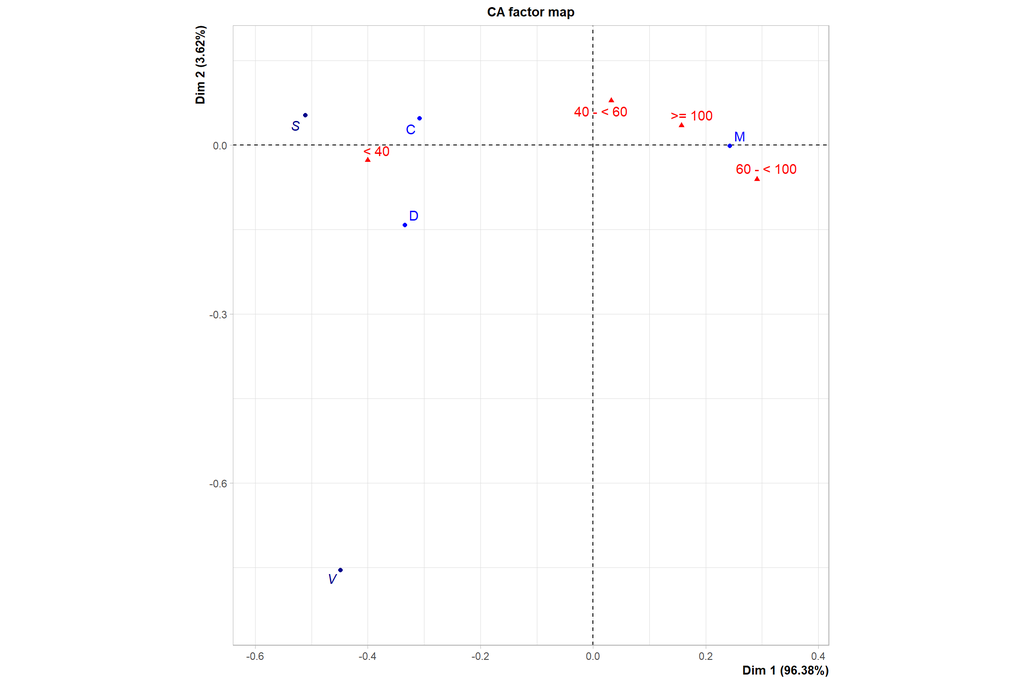

```r
res_ca3= CA(tb_cont %>% column_to_rownames('STAT_MARI'), ncp = 3, row.sup = c(4,5))
```

```r
summary(res_ca3)
```

```
##
## Call:
## CA(X = tb_cont %>% column_to_rownames("STAT_MARI"), ncp = 3,
##      row.sup = c(4, 5))
##
## The chi square of independence between the two variables is equal to 40.67807 (p-value =  3.350746e-07 ).
##
## Eigenvalues
##                        Dim.1   Dim.2
## Variance               0.076   0.003
## % of var.             96.380   3.620
## Cumulative % of var.  96.380 100.000
##
## Rows
##              Iner*1000    Dim.1    ctr   cos2    Dim.2    ctr   cos2
## C          |    32.082 | -0.308 41.090  0.977 |  0.047 25.836  0.023 |
## D          |    13.841 | -0.334 15.361  0.847 | -0.142 74.133  0.153 |
## M          |    33.218 |  0.243 43.549  1.000 | -0.001  0.031  0.000 |
##
## Columns
##              Iner*1000    Dim.1    ctr   cos2    Dim.2    ctr   cos2
## < 40       |    47.969 | -0.401 62.610  0.996 | -0.027  7.418  0.004 |
## >= 100     |     5.323 |  0.157  6.655  0.954 |  0.035  8.620  0.046 |
## 40 - < 60  |     1.611 |  0.032  0.295  0.140 |  0.079 48.396  0.860 |
## 60 - < 100 |    24.238 |  0.291 30.441  0.958 | -0.061 35.566  0.042 |
##
## Supplementary rows
##               Dim.1   cos2    Dim.2   cos2
## S          | -0.511  0.591 |  0.053  0.006 |
## V          | -0.449  0.254 | -0.755  0.719 |
```

On remarque maintenant que quasiment toute la variance est exprimée par un unique axe. Ceci semble donc indiquer une grande dépendance entre les deux variables, qui nous permet d'expliquer la plupart des différences de profils à l'aide des positions sur une seule dimension. Globalement on voit que cet axe donne des valeurs positives aux modalités de revenus les plus associés au statut *marié* et inversement.

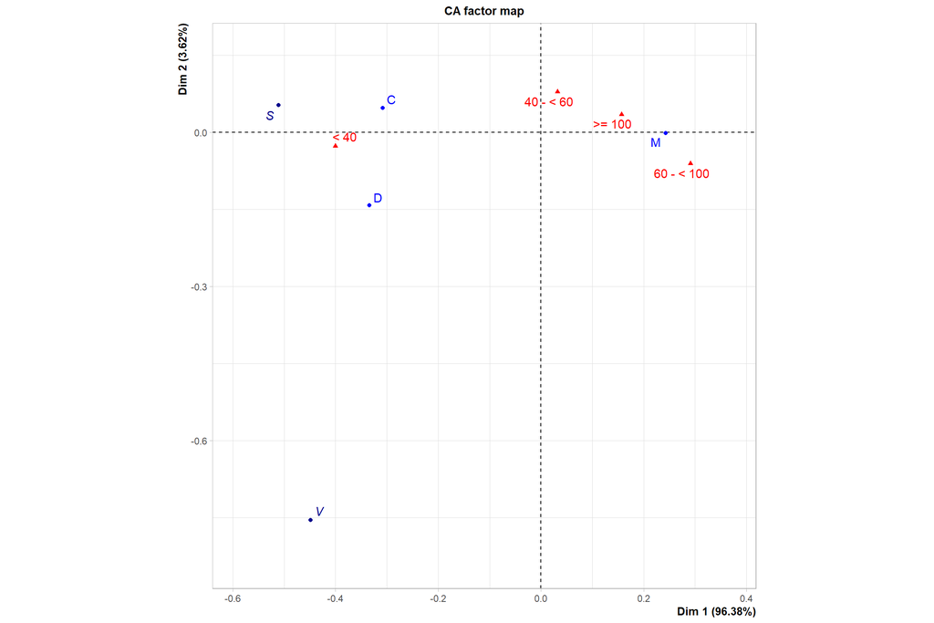

```r
plot(res_ca3)
```

```r
tb_cont
```

```
## # A tibble: 5 x 5
## # Groups:   STAT_MARI [5]
##   STAT_MARI `< 40` `>= 100` `40 - < 60` `60 - < 100`
##   <chr>      <dbl>    <dbl>       <dbl>        <dbl>
## 1 C             72       30          39           29
## 2 D             25        8           9           12
## 3 M             56       68          66          100
## 4 S              6        0           4            2
## 5 V              3        0           0            2
```

## Exercice 7

Pour ce nouvel exercice, une AFC complète va être effectuée sur une nouvelle base de données, directement présentée comme un tableau de contingence, contenue dans le fichier *media.csv*. Les variables mises en relation ici sont la catégorie socio-professionnelle avec le type de média favoris utilisé pour s'informer sur les thématiques environnementales. Chacune de ces variables présente différentes modalités qualitatives, comme nous allons le voir lors de la présentation ci-dessous à la suite du traditionel import des données et packages.

```r
rm(list = ls())

library(tidyverse)
library(gridExtra)
library(FactoMineR)

raw_db = read.csv2('C:/Users/user/Google Drive/Travail/Enseignement/STID/2A/ADD/Codes R/Donnees/media.csv')

raw_db
```

```
##      CSP TEL JOU RAD LIV ASS MAI Total
## 1  AGRI   26  18   9   5   4   6    68
## 2  CSUP   19  49   4  16   5   3    96
## 3  CMOY   44  87   4  39  14   3   191
## 4  EMPL   83  87  13  24   5   1   213
## 5  OUVR  181 107  16  31   7   7   349
## 6  RETR  167  95  29  15   7   7   320
## 7  CHOM   27   9   4   2   2   2    46
## 8 Total  547 452  79 132  44  29  1283
```

Cette fois, le tableau a le bon goût d'être déjà au format tidy, on pourra donc directement utiliser *raw_db* comme référence, et la variable *db* ci-dessous va être mise au format réclamé par la fonction *CA()* du package maintenant bien connu **FactoMineR**.

```r
db = raw_db %>% dplyr::select(- Total) %>%
                filter(CSP != 'Total ') %>%
                column_to_rownames('CSP')
db
```

```
##       TEL JOU RAD LIV ASS MAI
## AGRI   26  18   9   5   4   6
## CSUP   19  49   4  16   5   3
## CMOY   44  87   4  39  14   3
## EMPL   83  87  13  24   5   1
## OUVR  181 107  16  31   7   7
## RETR  167  95  29  15   7   7
## CHOM   27   9   4   2   2   2
```

On peut maintenant effectuer notre AFC en se rappelant que le nombre maximum d'axes est donné par min(m1, m2) - 1 = min(6, 7) - 1 = 5, dans notre cas de figure. Même s'il l'argument *graph* a par défaut une valeur égale à **TRUE**, nous le précisons ici explicitement pour indiquer qu'il est possible de désactiver l'affichage automatique des résultats.

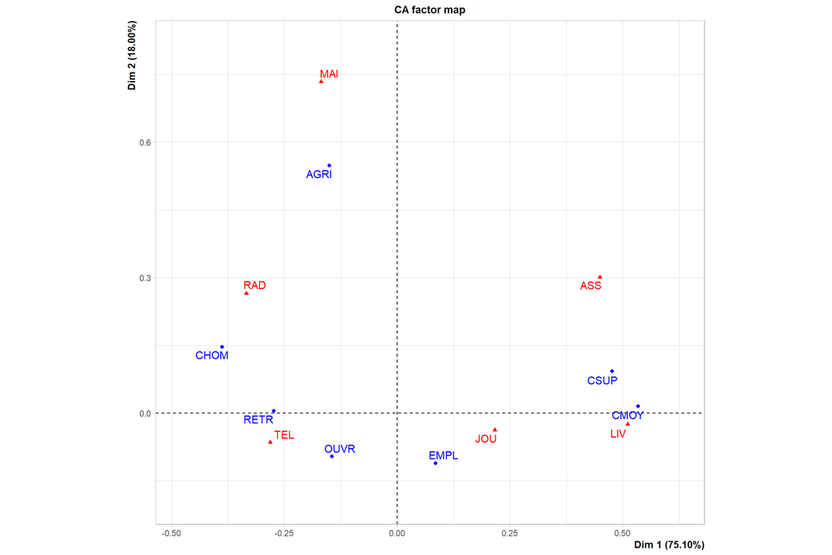

```r
media_AFC = CA(db, ncp = 5, graph = T)
```

Pour la suite, afin de clarifier le code et simplifier les multiples appels que l'on va faire aux différents résultats de l'AFC, on peut définir des variables *row*, *col* et *eig*. De manière générale, il faut savoir trouver un compromis entre garder une nombre réduit d'objets en mémoire dans l'environnement et la clarté/simplicité du code.

```r
row = media_AFC$row
col = media_AFC$col
eig = media_AFC$eig %>% data.frame %>%
                        rownames_to_column(var = 'Composante') %>%
                        as_tibble
```

Puis, comme nous en avons l'habitude, la selection du nombre d'axes à retenir peut se faire à l'aide de son critère favori concernant les valeurs propres et/ou la variance expliquée.

```r
eig
```

```
## # A tibble: 5 x 4
##   Composante eigenvalue percentage.of.variance cumulative.percentage.of.variance
##   <chr>           <dbl>                  <dbl>                             <dbl>
## 1 dim 1        0.0915                   75.1                                75.1
## 2 dim 2        0.0219                   18.0                                93.1
## 3 dim 3        0.00642                   5.27                               98.4
## 4 dim 4        0.00175                   1.44                               99.8
## 5 dim 5        0.000236                  0.194                             100.
```

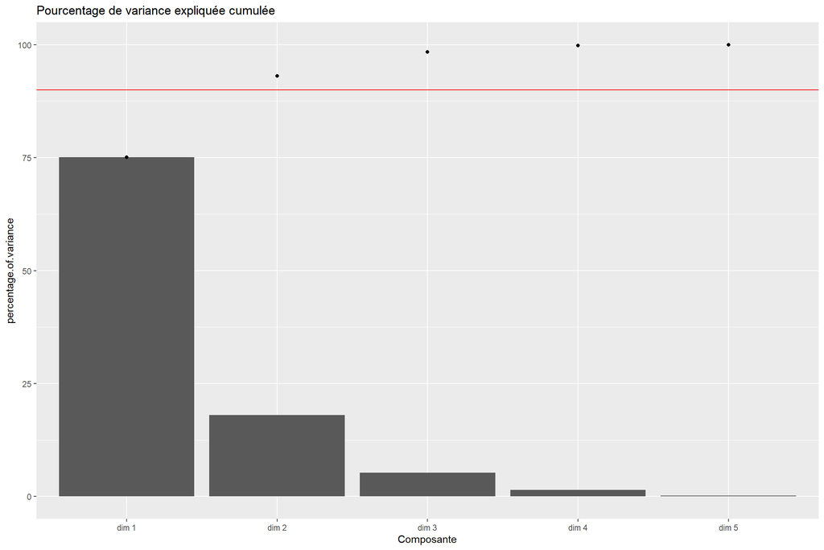

```r
eig %>% ggplot() + geom_col(aes(x = Composante, y = percentage.of.variance)) +
                   geom_point(aes(x = Composante, y = cumulative.percentage.of.variance)) +
                   ggtitle("Pourcentage de variance expliquée cumulée") +
                   geom_hline(aes(yintercept = 90), color = 'red')
```

Ici il peut sembler pertinent de garder seulement deux axes qui expliquent déjà plus de 90% de la variance. Un autre critère possible consiste à calculer la valeur moyenne des valeurs propres pour conserver celles qui lui sont supérieures.

```r
mean_eig = eig %>% pull(eigenvalue) %>%
                   mean()
```

Avec ce critère, nous n'aurions retenu qu'un axe, et très proche d'en conserver un deuxième (qui de toute façon ne 'coûte' rien lorsque l'on considère la projection sur un plan factoriel). Dans tous les cas, on voit que le premier axe rend compte à lui seul de l'information principale exprimée par nos données.

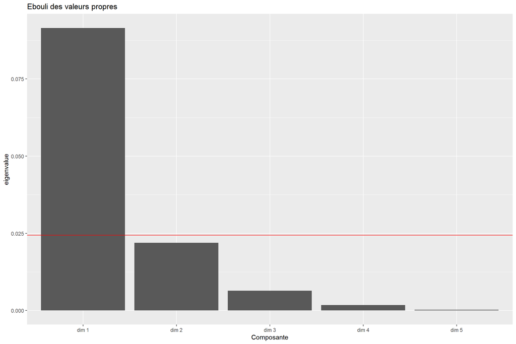

```r
eig %>% ggplot() + geom_col(aes(x = Composante, y = eigenvalue)) +
                   ggtitle("Ebouli des valeurs propres") +
                   geom_hline(aes(yintercept = mean_eig), color = 'red')
```

A la lumière de ces informations, nous pouvons maintenant analyser les contributions et qualités de représentations des différentes modalités sur ces 2 premières composantes principales, pour vérifier si elles sont toutes pertinentes. Gardons en tête pour les profils lignes et leurs 7 modalités, une contribution *moyenne* serait de l'ordre de $\frac{1}{7} \times100$ = 14.3%, et pour les profils colonnes de $\frac{1}{6} \times 100$ = 16.7%. Une contribution qui serait très inférieure à ces valeurs sur chaque axe retenu pourrait être considérée comme très peu utile à l'analyse, et potentiellement amener à basculer les modalités correspondantes en supplémentaires.

```r
row$contrib
```

```
##           Dim 1       Dim 2        Dim 3      Dim 4      Dim 5
## AGRI   1.298041 72.51327581  0.002768973  2.6703493 17.6761633
## CSUP  18.589655  2.92451563  9.926745975 27.4950684 31.7322241
## CMOY  46.346760  0.15573974 13.349957815 21.0009947  0.1650309
## EMPL   1.321123  9.41412708 27.118693446  0.4559869 27.3334060
## OUVR   6.216332 11.44358487 26.323414204 26.0420416  1.4375866
## RETR  20.336943  0.02474628 11.957637219 14.4076585 12.5171942
## CHOM   5.891148  3.52401058 11.320782369  7.9279006  9.1383948
```

```r
row$cos2
```

```
##            Dim 1        Dim 2        Dim 3       Dim 4        Dim 5
## AGRI  0.06913325 0.9257061924 1.034725e-05 0.002721255 2.428950e-03
## CSUP  0.90262553 0.0340366837 3.381821e-02 0.025544281 3.975290e-03
## CMOY  0.97116156 0.0007822194 1.962725e-02 0.008420048 8.922147e-06
## EMPL  0.23762891 0.4058757998 3.422412e-01 0.001569318 1.268475e-02
## OUVR  0.54971845 0.2425633799 1.633262e-01 0.044063983 3.279987e-04
## RETR  0.94635214 0.0002760159 3.904091e-02 0.012828122 1.502817e-03
## CHOM  0.76454800 0.1096223318 1.030834e-01 0.019686369 3.059896e-03
```

On peut voir dans ces deux tableaux que les modalités *Employé* et *Ouvrier* participent très peu à la création des axes, et en conséquence, sont assez mal représentés sur ceux-ci. Nous les considérerons donc comme modalités suppémentaires dans une nouvelle analyse. De même, nous pouvons analyser les profils colonnes à présent.

```r
col$contrib
```

```
##          Dim 1     Dim 2     Dim 3        Dim 4       Dim 5
## TEL 36.8359294  8.105340 12.263021  0.101198694  0.06006112
## JOU 18.0626422  2.242241 24.470862  6.402248871 13.59207658
## RAD  7.5070420 19.670247 33.990825 15.139456490 17.53498646
## LIV 29.3138808  0.282285 11.905792  0.004991968 48.20466391
## ASS  7.5764024 14.181452 12.054169 42.458147897 20.30036655
## MAI  0.7041032 55.518435  5.315332 35.893956080  0.30784537
```

```r
col$cos2
```

```
##         Dim 1       Dim 2      Dim 3        Dim 4        Dim 5
## TEL 0.9292328 0.049009593 0.02170490 4.884615e-05 3.909113e-06
## JOU 0.8821972 0.026249659 0.08385735 5.983007e-03 1.712782e-03
## RAD 0.5024225 0.315549146 0.15961341 1.938711e-02 3.027873e-03
## LIV 0.9661362 0.002230025 0.02753156 3.148034e-06 4.099077e-03
## ASS 0.5972194 0.267946782 0.06666771 6.403751e-02 4.128637e-03
## MAI 0.0467158 0.882920663 0.02474374 4.556710e-02 5.269775e-05
```

Ici les modalités *Radio* et *Associations* sont assez mal représentées et l'on peut choisir de les basculer en supplémentaires. Dans ces conditions, le nombre maximum d'axe tombe à présent à 3.

```r
media_AFC2 = CA(db, ncp = 2, row.sup = c(4,5), col.sup = c(3,5), graph = F)
```

```r
row = media_AFC2$row
col = media_AFC2$col
eig = media_AFC2$eig %>% data.frame %>%
                        rownames_to_column(var = 'Composante') %>%
                        as_tibble
```

```r
eig
```

```
## # A tibble: 3 x 4
##   Composante eigenvalue percentage.of.variance cumulative.percentage.of.variance
##   <chr>           <dbl>                  <dbl>                             <dbl>
## 1 dim 1         0.139                    86.5                               86.5
## 2 dim 2         0.0183                   11.4                               97.9
## 3 dim 3         0.00339                   2.11                             100
```

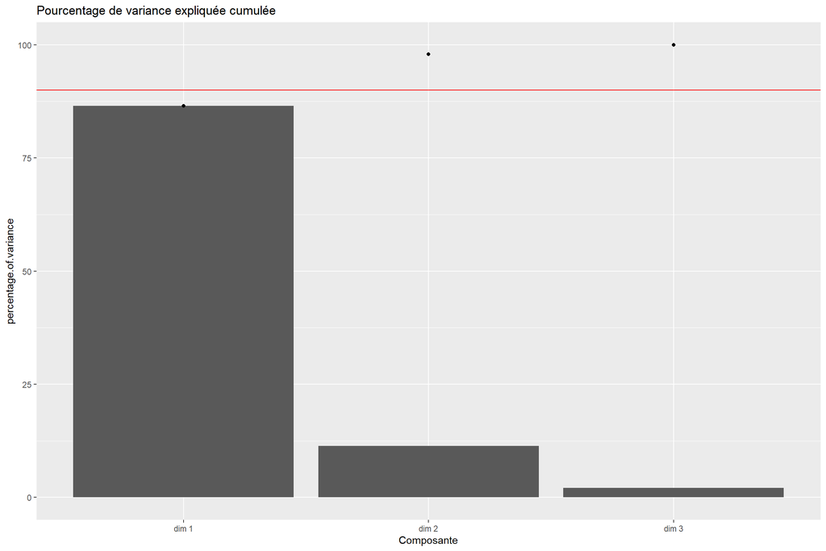

```r
eig %>% ggplot() + geom_col(aes(x = Composante, y = percentage.of.variance)) +
                   geom_point(aes(x = Composante, y = cumulative.percentage.of.variance)) +
                   ggtitle("Pourcentage de variance expliquée cumulée") +
                   geom_hline(aes(yintercept = 90), color = 'red')
```

On peut voir à présent que la selection de deux axes est assez naturelle. Vérifions que toutes nos modalités contribuent correctement à leur création.

```r
row$contrib
```

```
##           Dim 1     Dim 2
## AGRI   1.784454 80.674424
## CSUP  19.261376  1.581422
## CMOY  38.507944  2.847088
## RETR  29.830579 13.831766
## CHOM  10.615646  1.065300
```

```r
col$contrib
```

```
##          Dim 1       Dim 2
## TEL 46.9857173  3.15322896
## JOU 18.0168654  1.07243060
## LIV 34.1724121  0.03612171
## MAI  0.8250051 95.73821874
```

Ainsi que la qualité de leur représentation.

```r
row$cos2
```

```
##           Dim 1       Dim 2
## AGRI  0.1438487 0.855797563
## CSUP  0.9365794 0.010119046
## CMOY  0.9735759 0.009472286
## RETR  0.9385876 0.057269747
## CHOM  0.9403323 0.012417706
```

```r
col$cos2
```

```
##          Dim 1        Dim 2
## TEL 0.98841492 0.0087289788
## JOU 0.94105033 0.0073711851
## LIV 0.96297248 0.0001339495
## MAI 0.06144284 0.9382843034
```

En plus de voir que les modalités sont en effet bien représentées on remarque que le deuxième axe est construit quasi exclusivement par les modalités *Agriculteur* et *Mairie* alors que les autres sont plus équilibrées su le premier axe. Ces informations sont importantes à retenir pour l'analyse des coordonnées de chaque modalité sur les axes retenus, dans le tableau ci-dessous.

```r
row$coord
```

```
##            Dim 1       Dim 2
## AGRI  -0.1698596  0.41430735
## CSUP   0.4437137  0.04612117
## CMOY   0.4449087 -0.04388473
## RETR  -0.3056261 -0.07549456
## CHOM  -0.4858050  0.05582671
```

```r
col$coord
```

```
##          Dim 1       Dim 2
## TEL -0.3842452 -0.03610943
## JOU  0.2492003 -0.02205519
## LIV  0.6282193  0.00740926
## MAI -0.1869121  0.73041396
```

Ou plus simplement, via la projection dans le premier plan factoriel, que l'on peut également analyser en s'aidant du tableau de contingence brut.

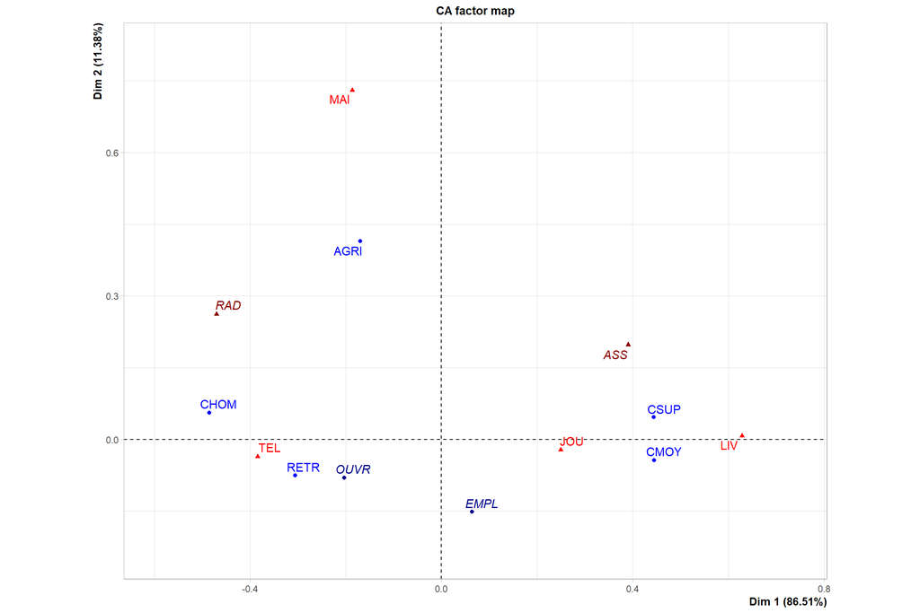

```r
plot(media_AFC2)
```

```r
raw_db
```

```
##      CSP TEL JOU RAD LIV ASS MAI Total
## 1  AGRI   26  18   9   5   4   6    68
## 2  CSUP   19  49   4  16   5   3    96
## 3  CMOY   44  87   4  39  14   3   191
## 4  EMPL   83  87  13  24   5   1   213
## 5  OUVR  181 107  16  31   7   7   349
## 6  RETR  167  95  29  15   7   7   320
## 7  CHOM   27   9   4   2   2   2    46
## 8 Total  547 452  79 132  44  29  1283
```

Concernant le premier axe à présent, on voit une nette opposition entre les modalités de médias 'papier' avec des coordonnées positives, tout comme les CSP moyennes ou supérieurs, probablement parmi les plus 'éduqués' dans les catégories proposées. De l'autre côté de l'axe, les modalités 'Chômeurs', 'Ouvriers' et 'Retraités' sont plus associés aux média *Radio* ou *Télévisuels.* Tandis que les employés ont un profil à mi chemin.

## Exercice 8

Cet exercice se concentre sur l'analyse de la base de données *Papillon*, qui regroupe 23 papillons sur lesquels sont observés 4 caratéristiques quantitatives discrètes notées $Z_1$, $Z_2$, $Z_3$ et $Z_4$. Nous allons tâcher de les analyser en nous appuyant sur une ACP puis sur une AFC, pour comparer les résultats apportés par les deux approches. Comme d'habitude, nous importons les packages, les données, et supprimons la colonne complétement futile qui comporte les numéros de ligne.

```r
rm(list = ls())

library(tidyverse)
library(gridExtra)
library(FactoMineR)

raw_db = read.csv2('C:/Users/user/Google Drive/Travail/Enseignement/STID/2A/ADD/Codes R/Donnees/Papillon.csv')

raw_db
```

```
##    NUM Z1 Z2 Z3 Z4
## 1    1 22 35 24 19
## 2    2 24 31 21 22
## 3    3 27 36 25 15
## 4    4 27 36 24 23
## 5    5 21 33 23 18
## 6    6 26 35 23 32
## 7    7 27 37 26 15
## 8    8 22 30 19 20
## 9    9 25 33 22 22
## 10  10 30 41 28 17
## 11  11 24 39 27 21
## 12  12 29 39 27 17
## 13  13 29 40 27 17
## 14  14 28 36 23 24
## 15  15 22 36 24 20
## 16  16 23 30 20 20
## 17  17 28 38 26 16
## 18  18 25 34 23 14
## 19  19 26 35 24 15
## 20  20 23 37 25 20
## 21  21 31 42 29 18
## 22  22 26 34 22 21
## 23  23 24 38 26 21
```

```r
db = raw_db %>% select(- NUM)


db
```

```
##    Z1 Z2 Z3 Z4
## 1  22 35 24 19
## 2  24 31 21 22
## 3  27 36 25 15
## 4  27 36 24 23
## 5  21 33 23 18
## 6  26 35 23 32
## 7  27 37 26 15
## 8  22 30 19 20
## 9  25 33 22 22
## 10 30 41 28 17
## 11 24 39 27 21
## 12 29 39 27 17
## 13 29 40 27 17
## 14 28 36 23 24
## 15 22 36 24 20
## 16 23 30 20 20
## 17 28 38 26 16
## 18 25 34 23 14
## 19 26 35 24 15
## 20 23 37 25 20
## 21 31 42 29 18
## 22 26 34 22 21
## 23 24 38 26 21
```

```r
summary(db)
```

```
##        Z1              Z2              Z3              Z4
##  Min.   :21.00   Min.   :30.00   Min.   :19.00   Min.   :14.00
##  1st Qu.:23.50   1st Qu.:34.00   1st Qu.:23.00   1st Qu.:17.00
##  Median :26.00   Median :36.00   Median :24.00   Median :20.00
##  Mean   :25.61   Mean   :35.87   Mean   :24.26   Mean   :19.43
##  3rd Qu.:27.50   3rd Qu.:38.00   3rd Qu.:26.00   3rd Qu.:21.00
##  Max.   :31.00   Max.   :42.00   Max.   :29.00   Max.   :32.00
```

Après un premier summary, nous pouvons noter en étant bien attentif que toutes les variables ont l'air relativement homogènes, hormis Z4, dont le max semble beaucoup plus grand que le 3ème quartile. Regardons ça de plus prêt dans l'ACP qui suit.

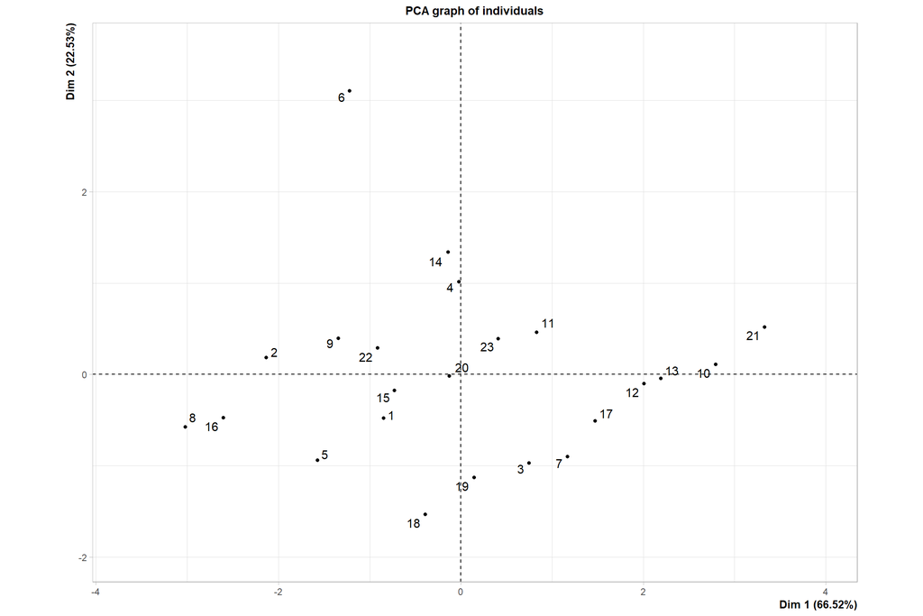

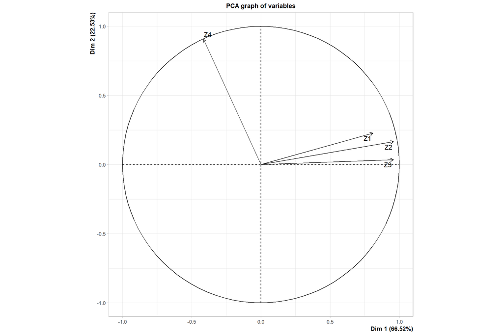

```r
res_acp = PCA(db, ncp = 4)
```

Sur le plan factoriel, il semble y avoir un individu atypique, et en observant les données brutes, il s'agit en fait de l'individu avec une très grand valeur de $Z_4$.

```r
summary(res_acp)
```

```
##
## Call:
## PCA(X = db, ncp = 4)
##
##
## Eigenvalues
##                        Dim.1   Dim.2   Dim.3   Dim.4
## Variance               2.661   0.901   0.423   0.015
## % of var.             66.518  22.531  10.582   0.369
## Cumulative % of var.  66.518  89.049  99.631 100.000
##
## Individuals (the 10 first)
##        Dist    Dim.1    ctr   cos2    Dim.2    ctr   cos2    Dim.3    ctr
## 1  |  1.359 | -0.850  1.180  0.391 | -0.477  1.096  0.123 |  0.947  9.204
## 2  |  2.209 | -2.135  7.447  0.934 |  0.184  0.164  0.007 | -0.495  2.515
## 3  |  1.303 |  0.746  0.910  0.328 | -0.968  4.521  0.552 | -0.436  1.955
## 4  |  1.069 | -0.021  0.001  0.000 |  1.016  4.981  0.903 | -0.332  1.131
## 5  |  2.017 | -1.572  4.038  0.607 | -0.939  4.252  0.217 |  0.834  7.141
## 6  |  3.342 | -1.223  2.443  0.134 |  3.108 46.587  0.864 |  0.004  0.000
## 7  |  1.491 |  1.168  2.227  0.613 | -0.899  3.895  0.363 | -0.160  0.263
## 8  |  3.110 | -3.023 14.929  0.944 | -0.575  1.594  0.034 | -0.400  1.642
## 9  |  1.465 | -1.346  2.962  0.844 |  0.397  0.759  0.073 | -0.416  1.780
## 10 |  2.806 |  2.793 12.749  0.991 |  0.113  0.062  0.002 | -0.239  0.586
##      cos2
## 1   0.485 |
## 2   0.050 |
## 3   0.112 |
## 4   0.096 |
## 5   0.171 |
## 6   0.000 |
## 7   0.012 |
## 8   0.017 |
## 9   0.081 |
## 10  0.007 |
##
## Variables
##       Dim.1    ctr   cos2    Dim.2    ctr   cos2    Dim.3    ctr   cos2
## Z1 |  0.810 24.647  0.656 |  0.227  5.731  0.052 | -0.541 69.095  0.292 |
## Z2 |  0.957 34.451  0.917 |  0.165  3.035  0.027 |  0.220 11.451  0.048 |
## Z3 |  0.957 34.452  0.917 |  0.034  0.132  0.001 |  0.274 17.745  0.075 |
## Z4 | -0.414  6.449  0.172 |  0.906 91.102  0.821 |  0.085  1.709  0.007 |
```

```r
res_acp = PCA(db, ncp = 4, ind.sup= 6, graph = F)
```

Comme habituellement, selectionnons le nombre adequat d'axes factoriels à considérer. Si l'on suit la règle de Kayser, seul un axe serait retenu, à peu de choses près.

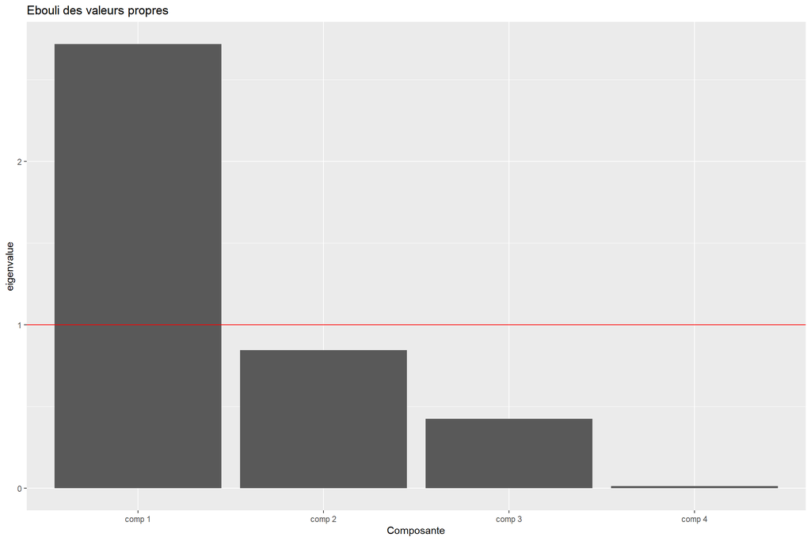

```r
vp = res_acp$eig %>% data.frame %>% rownames_to_column(var = 'Composante') %>% as_tibble

ggplot(vp) + geom_col(aes(x = Composante, y = eigenvalue)) +
             ggtitle("Ebouli des valeurs propres") +
             geom_hline(aes(yintercept = 1), color = 'red')
```

Comme déjà discuté, l'intérêt de ne retenir qu'un seul axe est faible, dans le sens où il est quasiment 'gratuit' de considérer les deux premiers axes d'un point de vu graphique. De plus, nous voyons avec un autre critère de choix que pour atteindre environ 90% de variance expliquée, il serait nécessaire de retenir deux composantes principales. Nous gardons donc ce choix de deux axes pour la suite de l'analyse.

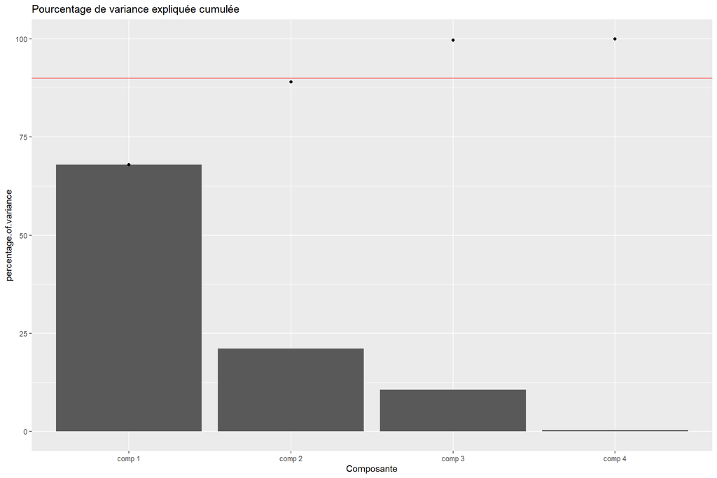

```r
ggplot(vp) + geom_col(aes(x = Composante, y = percentage.of.variance)) +
             geom_point(aes(x = Composante, y = cumulative.percentage.of.variance)) +
             ggtitle("Pourcentage de variance expliquée cumulée") +
             geom_hline(aes(yintercept = 90), color = 'red')
```

Sachant que nous avons déjà retiré l'individu semblant le plus aberrant, concentrons nous à présent sur les variables, leurs contributions respectives et leurs qualités de représentation. D'une part pour voir si elles sont toutes utiles, et pour donner des premiers indices sur l'interprétation à suivre que l'on devra faire des composantes principales.

```r
summary(res_acp)
```

```
##
## Call:
## PCA(X = db, ncp = 4, ind.sup = 6, graph = F)
##
##
## Eigenvalues
##                        Dim.1   Dim.2   Dim.3   Dim.4
## Variance               2.717   0.845   0.425   0.013
## % of var.             67.925  21.118  10.629   0.328
## Cumulative % of var.  67.925  89.043  99.672 100.000
##
## Individuals (the 10 first)
##        Dist    Dim.1    ctr   cos2    Dim.2    ctr   cos2    Dim.3    ctr
## 1  |  1.324 | -0.889  1.323  0.451 | -0.238  0.305  0.032 | -0.952  9.682
## 2  |  2.371 | -2.248  8.457  0.899 |  0.471  1.195  0.040 |  0.536  3.066
## 3  |  1.501 |  0.832  1.158  0.307 | -1.205  7.807  0.644 |  0.323  1.116
## 4  |  1.574 | -0.243  0.099  0.024 |  1.486 11.876  0.891 |  0.455  2.210
## 5  |  1.971 | -1.546  4.001  0.616 | -0.829  3.698  0.177 | -0.889  8.454
## 7  |  1.654 |  1.239  2.567  0.561 | -1.087  6.359  0.432 |  0.058  0.036
## 8  |  3.096 | -3.028 15.343  0.957 | -0.484  1.260  0.024 |  0.368  1.450
## 9  |  1.721 | -1.485  3.691  0.744 |  0.721  2.795  0.175 |  0.478  2.439
## 10 |  2.747 |  2.732 12.482  0.989 |  0.151  0.123  0.003 |  0.238  0.604
## 11 |  1.718 |  0.654  0.715  0.145 |  0.986  5.229  0.329 | -1.244 16.544
##      cos2
## 1   0.517 |
## 2   0.051 |
## 3   0.046 |
## 4   0.083 |
## 5   0.204 |
## 7   0.001 |
## 8   0.014 |
## 9   0.077 |
## 10  0.007 |
## 11  0.524 |
##
## Supplementary individual
##        Dist    Dim.1   cos2    Dim.2   cos2    Dim.3   cos2
## 6  |  4.757 | -1.780  0.140 |  4.385  0.850 |  0.375  0.006 |
##
## Variables
##       Dim.1    ctr   cos2    Dim.2    ctr   cos2    Dim.3    ctr   cos2
## Z1 |  0.820 24.745  0.672 |  0.145  2.478  0.021 |  0.554 72.122  0.307 |
## Z2 |  0.949 33.156  0.901 |  0.224  5.966  0.050 | -0.205  9.894  0.042 |
## Z3 |  0.953 33.415  0.908 |  0.097  1.124  0.009 | -0.276 17.968  0.076 |
## Z4 | -0.486  8.683  0.236 |  0.874 90.432  0.764 | -0.008  0.016  0.000 |
```

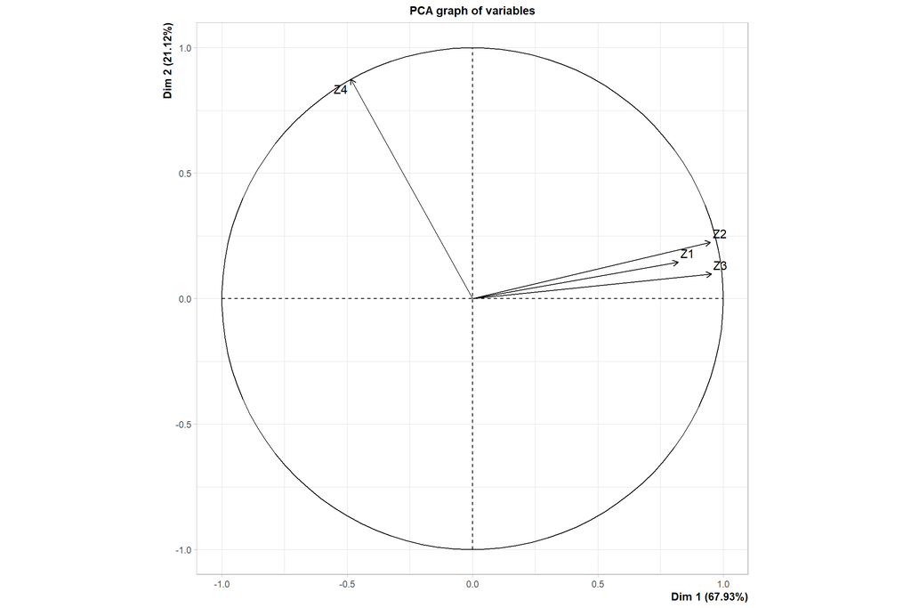

```r
plot(res_acp, axes = c(1,2), choix = 'var')
```